# Does Anticoagulation Prevent Thrombus Formation in Cardiac Amyloidosis?

## 0.1 Preliminaries

```r
library(arm)
library(leaps)
library(tableone)
library(pander)
library(ROCR)
library(skimr)
library(rms)
library(broom)
library(tidyverse)
```

# 1 Task 1: Data Source

The data set I hope to use for Project 1 is one that I built of patients with cardiac amylodosis who underwent a transesophageal echocardiogram (TEE) at the Cleveland Clinic from 2010-2016.Because the data has been fully de-identified of any PHI and the project is part of a Masters program being funded by the Cleveland Clinic the data has been approved by the IRB for sharing as part of my coursework.

## 1.1 Background

Cardiac amyloidosis is an infiltriltrative disorder in which protein plaques called amyloid take over the normal muscle of the heart. The heart becomes stiff creating an environment of slow flow. Because of this slow flow state, patients with cardiac amyloidosis are prone to developing blood clots (thrombus) within their atria. For years, patients with cardiac amyloidosis at risk for clots have been treated with traditional anticoagulation. We have observed a number of amyloid patients who developed clots despite therapeutic anticoagluation. The goal of our study is to see if therapeutic anticoagulation is associated with a decreased risk of clot formation. If these patients with cardiac amyloid do develop clots despite anticoagulation they may be good candidates for early treatment with intracardiac devices (such as the Watchman) that effectively exclude portions of the left atrium to prevent the development of left atrial thrombus.

## 1.2 Data Collection Process

The clinic has a database that includes a list of patients with cardiac amyloidosis. I cross-matched this database with our echo database to filter only patients who underwent transesophageal echocardiogram from 2010-2016. For each subject I found the transesophageal echocardiogram report and pulled the following information directly from the report:

- Age at time of TEE
- Sex
- Indication for TEE test
- primary rhythm
- Type of test (OR TEE vs regular TEE)
- Left atrial appendage thrombus, sludge, or smoke presence
- Right atrial thrombus presence
- Left ventricular ejection fraction
- Left atrial emptying velocity
- Left atrial filling velocity

From the most recent clinic encounter I obtained information regarding:

- Whether or not the patient had been on outpatient anticoagulation for at least 6 weeks or inpatient anticoagulation for 48 hours
- Type of anticoagulation if present

I then found the most recent clinic encounter before the TEE and noted if the patient had a history of the following comorbidities:

- Hypertension
- Congestive Heart Failure
- Stroke (CVA)
- Peripheral Arterial Disease (PAD)
- Coronary Artery Disease (CAD)

From the most recent ECG prior to the TEE I gathered the following data: * Does the patient meet criteria of low voltage per the formal ECG interpretation

All of the above data was gathered directly from the patient chart. Using the above data I calculated the patient’s [CHADS2](http://www.medcalc.com/chads2-score-atrial-fibrillation-stroke-risk.html) and [CHADS2VA2Sc](http://www.medcalc.com/cha2ds2-score-atrial-fibrillation-stroke-risk.html) Scores. These scores are estimates of the patient’s annual risk of stroke. More details can be found at the links.

## 1.3 Building the database and PHI

Patient data was gathered under randomly assigned subject numbers thus no PHI was included in the database to allow free sharing. In the context of this course.

# 2 Task 2: Load and Tidy the Data

## 2.1 Loading Amyloid Data

```r
amyloid<-read.csv("amyloid_tee_data.csv",header=T,na.strings="") %>% tbl_df()
```

```r
skim_with(numeric=list(hist=NULL),integer=list(hist=NULL))
 skim(amyloid)
```

```
Skim summary statistics
 n obs: 120
 n variables: 23

Variable type: factor
    variable missing complete   n n_unique
  indication       0      120 120       28
 primary_rhy       0      120 120       13
         sex       0      120 120        2
   test_type       0      120 120        2
                            top_counts ordered
 Atr: 43, End: 10, Aor: 8, Int: 8        FALSE
      Sin: 44, Atr: 43, Atr: 8, V. : 8   FALSE
              M: 85, F: 35, NA: 0        FALSE
          TEE: 78, ORE: 42, NA: 0        FALSE

Variable type: integer
      variable missing complete   n     mean    sd   p0     p25 median
            AF       0      120 120    0.48   0.5     0    0       0
           age       0      120 120   69.88  10.63   44   64      71
     age_score       0      120 120    1.09   0.81    0    0       1
      Anticoag       0      120 120    0.5    0.5     0    0       0.5
 anticoag_type       0      120 120    0.78   0.92    0    0       0.5
           CAD       0      120 120    0.59   0.49    0    0       1
  CHADS2.Score       0      120 120    2.47   1.3     0    1.75    2
     CHADSVASC       0      120 120    4      1.68    0    3       4
           CHF       0      120 120    0.9    0.3     0    1       1
           CVA       0      120 120    0.25   0.51    0    0       0
          Diab       0      120 120    0.23   0.42    0    0       0
     high_risk       0      120 120    0.44   0.5     0    0       0
           HTN       0      120 120    0.52   0.5     0    0       1
  laa_thrombus       0      120 120    1      1.28    0    0       0
      low_volt       0      120 120    0.13   0.34    0    0       0
          lvef       0      120 120   45.59  13.73   10   35      47.5
           PAD       0      120 120    0.033  0.18    0    0       0
   ra_thrombus       0      120 120    0.033  0.18    0    0       0
       subject       0      120 120 1060.5   34.79 1001 1030.75 1060.5
     p75 p100
    1       1
   77      91
    2       2
    1       1
    1       3
    1       1
    3       6
    5       8
    1       1
    0       2
    0       1
    1       1
    1       1
    3       3
    0       1
   55      75
    0       1
    0       1
 1090.25 1120
```

The original data set contains 120 observations on 23 variables. There are no observations with missing variables.

## 2.2 Tidy Data

### 2.2.1 Select Relevant Variables

We now need to select the variables that we think could be important for our planned project analyses. We will leave out the AF (or atrial fibrillation category) from the database as we want to make sure we are capturing patients with both atrial fibrillation and atrial flutter.

```r
amyloid1<-amyloid %>%
  select(subject,age,sex,lvef,anticoag_type,Anticoag,primary_rhy,CHADSVASC,high_risk,laa_thrombus,HTN,Diab,CHF,CAD)
```

```r
skim(amyloid1)
```

```
Skim summary statistics
 n obs: 120
 n variables: 14

Variable type: factor
    variable missing complete   n n_unique
 primary_rhy       0      120 120       13
         sex       0      120 120        2
                       top_counts ordered
 Sin: 44, Atr: 43, Atr: 8, V. : 8   FALSE
         M: 85, F: 35, NA: 0        FALSE

Variable type: integer
      variable missing complete   n    mean    sd   p0     p25 median
           age       0      120 120   69.88 10.63   44   64      71
      Anticoag       0      120 120    0.5   0.5     0    0       0.5
 anticoag_type       0      120 120    0.78  0.92    0    0       0.5
           CAD       0      120 120    0.59  0.49    0    0       1
     CHADSVASC       0      120 120    4     1.68    0    3       4
           CHF       0      120 120    0.9   0.3     0    1       1
          Diab       0      120 120    0.23  0.42    0    0       0
     high_risk       0      120 120    0.44  0.5     0    0       0
           HTN       0      120 120    0.52  0.5     0    0       1
  laa_thrombus       0      120 120    1     1.28    0    0       0
          lvef       0      120 120   45.59 13.73   10   35      47.5
       subject       0      120 120 1060.5  34.79 1001 1030.75 1060.5
     p75 p100
   77      91
    1       1
    1       3
    1       1
    5       8
    1       1
    0       1
    1       1
    1       1
    3       3
   55      75
 1090.25 1120
```

We can see from this initial skim that we have no missing data.

We need to do some tidying of the variables that we have left.

### 2.2.2 Tidy Factors

The factor variable that needs the most tidying is `primary_rhy`. We see that we have 13 unique values. We can look at the levels of this factor by performing a summary.

```r
summary(amyloid$primary_rhy)
```

```
       A.paced     Atrial fib     Atrial Fib Atrial flutter Atrial Flutter
             1              8             43              1              7
      AV paced       AV Paced    Heart block          sinus          Sinus
             1              3              1              1             44
    Sinus LBBB       V. Paced        V.paced
             1              8              1
```

We can see that several of the same rhythms were documented using slightly different names/capitalization formats. So we’d like to collapse some of these categories. We will collapse down from 13 to 3 clinically relevant categories.

There are also a few categorical variables that are down as integers with more than two levels (so 0,1,2,etc.) that we’d like to turn into factors to remove the confusion of dealing with non 0/1 numbers. We will give each of these variable values specific labels when we convert them to factors to avoid confusion down the line.

We will create a binary sex variable called `female` and a binary factor designating whether or not the person had atrial fibrillation called `af_f` and a binary integer variable called`af` in case we want to use ols or lrm methods.

We will also collapse a patient’s CHADSVASC score into the clinically relevent low, moderate, and high risk categories.

```r
amyloid2<-amyloid1%>%
  mutate(primary_rhy=fct_collapse(factor(primary_rhy),"1_afib.flut"=c("Atrial fib", "Atrial Fib","Atrial Flutter","Atrial flutter"),"2_paced"=c("AV paced","A.paced","AV Paced","V. Paced","V.paced","Heart block"),"3_sinus"=c("sinus","Sinus","Sinus LBBB")),
         af_f=fct_collapse(factor(primary_rhy),"Yes"="1_afib.flut","No"=c("2_paced","3_sinus")),
         af=as.integer(af_f),
         af=af-1,
         anticoag_type=fct_recode(factor(anticoag_type),"0_none"="0","1_warfarin"="1","2_heparin"="2","3_noac"="3"),
         laa_thrombus=fct_recode(factor(laa_thrombus),"0_none"="0","1_thrombus"="1","2_sludge"="2","3_smoke"="3"),
female=as.integer(sex),
female=female-1,
CHAD.cat=fct_collapse(factor(CHADSVASC),"0_low"="0","1_mod"="1","2_high"=c("2","3","4","5","6","7","8","9")))
```

### 2.2.3 Create Final Tibble

After cleaning I will designate a final working tibble amyloid.f.

```r
amyloid.f<-amyloid2
```

# 3 Task 3: Listing of My Tibble

```r
glimpse(amyloid.f)
```

```
Observations: 120
Variables: 18
$ subject       <int> 1001, 1002, 1003, 1004, 1005, 1006, 1007, 1008, ...
$ age           <int> 66, 85, 78, 60, 84, 80, 63, 80, 79, 77, 78, 46, ...
$ sex           <fct> M, F, M, M, M, M, M, F, F, M, M, F, M, M, F, M, ...
$ lvef          <int> 25, 25, 40, 20, 50, 55, 65, 56, 64, 20, 35, 45, ...
$ anticoag_type <fct> 2_heparin, 0_none, 1_warfarin, 0_none, 0_none, 1...
$ Anticoag      <int> 1, 0, 1, 0, 0, 1, 0, 1, 0, 1, 1, 0, 1, 1, 1, 1, ...
$ primary_rhy   <fct> 1_afib.flut, 1_afib.flut, 1_afib.flut, 3_sinus, ...
$ CHADSVASC     <int> 3, 8, 4, 6, 4, 3, 3, 8, 8, 4, 4, 2, 3, 3, 7, 3, ...
$ high_risk     <int> 0, 1, 1, 1, 0, 1, 0, 0, 0, 1, 1, 0, 1, 1, 0, 1, ...
$ laa_thrombus  <fct> 0_none, 2_sludge, 2_sludge, 3_smoke, 0_none, 3_s...
$ HTN           <int> 0, 1, 0, 1, 1, 1, 1, 1, 1, 1, 1, 0, 1, 1, 1, 0, ...
$ Diab          <int> 1, 1, 1, 1, 0, 1, 0, 1, 1, 0, 0, 0, 1, 1, 0, 0, ...
$ CHF           <int> 1, 1, 1, 1, 1, 1, 1, 1, 1, 1, 1, 1, 0, 0, 1, 1, ...
$ CAD           <int> 0, 0, 0, 1, 0, 1, 1, 1, 1, 1, 1, 1, 0, 0, 0, 0, ...
$ af_f          <fct> Yes, Yes, Yes, No, No, No, No, Yes, No, Yes, Yes...
$ af            <dbl> 1, 1, 1, 0, 0, 0, 0, 1, 0, 1, 1, 0, 1, 1, 1, 1, ...
$ female        <dbl> 1, 0, 1, 1, 1, 1, 1, 0, 0, 1, 1, 0, 1, 1, 0, 1, ...
$ CHAD.cat      <fct> 2_high, 2_high, 2_high, 2_high, 2_high, 2_high, ...
```

```r
skim(amyloid.f)
```

```
Skim summary statistics
 n obs: 120
 n variables: 18

Variable type: factor
      variable missing complete   n n_unique
          af_f       0      120 120        2
 anticoag_type       0      120 120        4
      CHAD.cat       0      120 120        3
  laa_thrombus       0      120 120        4
   primary_rhy       0      120 120        3
           sex       0      120 120        2
                        top_counts ordered
            No: 61, Yes: 59, NA: 0   FALSE
 0_n: 60, 1_w: 34, 2_h: 19, 3_n: 7   FALSE
   2_h: 117, 1_m: 2, 0_l: 1, NA: 0   FALSE
 0_n: 67, 3_s: 31, 1_t: 17, 2_s: 5   FALSE
  1_a: 59, 3_s: 46, 2_p: 15, NA: 0   FALSE
               M: 85, F: 35, NA: 0   FALSE

Variable type: integer
  variable missing complete   n    mean    sd   p0     p25 median     p75
       age       0      120 120   69.88 10.63   44   64      71     77
  Anticoag       0      120 120    0.5   0.5     0    0       0.5    1
       CAD       0      120 120    0.59  0.49    0    0       1      1
 CHADSVASC       0      120 120    4     1.68    0    3       4      5
       CHF       0      120 120    0.9   0.3     0    1       1      1
      Diab       0      120 120    0.23  0.42    0    0       0      0
 high_risk       0      120 120    0.44  0.5     0    0       0      1
       HTN       0      120 120    0.52  0.5     0    0       1      1
      lvef       0      120 120   45.59 13.73   10   35      47.5   55
   subject       0      120 120 1060.5  34.79 1001 1030.75 1060.5 1090.25
 p100
   91
    1
    1
    8
    1
    1
    1
    1
   75
 1120

Variable type: numeric
 variable missing complete   n mean   sd p0 p25 median p75 p100
       af       0      120 120 0.49 0.5   0   0      0   1    1
   female       0      120 120 0.71 0.46  0   0      1   1    1
```

For unclear reasons our newly created sex variables are showing up as numeric instead of integer so we will fix these again.

```r
amyloid.f$af<-as.integer(amyloid.f$af)
amyloid.f$female<-as.integer(amyloid.f$female)
```

```r
skim(amyloid.f)
```

```
Skim summary statistics
 n obs: 120
 n variables: 18

Variable type: factor
      variable missing complete   n n_unique
          af_f       0      120 120        2
 anticoag_type       0      120 120        4
      CHAD.cat       0      120 120        3
  laa_thrombus       0      120 120        4
   primary_rhy       0      120 120        3
           sex       0      120 120        2
                        top_counts ordered
            No: 61, Yes: 59, NA: 0   FALSE
 0_n: 60, 1_w: 34, 2_h: 19, 3_n: 7   FALSE
   2_h: 117, 1_m: 2, 0_l: 1, NA: 0   FALSE
 0_n: 67, 3_s: 31, 1_t: 17, 2_s: 5   FALSE
  1_a: 59, 3_s: 46, 2_p: 15, NA: 0   FALSE
               M: 85, F: 35, NA: 0   FALSE

Variable type: integer
  variable missing complete   n    mean    sd   p0     p25 median     p75
        af       0      120 120    0.49  0.5     0    0       0      1
       age       0      120 120   69.88 10.63   44   64      71     77
  Anticoag       0      120 120    0.5   0.5     0    0       0.5    1
       CAD       0      120 120    0.59  0.49    0    0       1      1
 CHADSVASC       0      120 120    4     1.68    0    3       4      5
       CHF       0      120 120    0.9   0.3     0    1       1      1
      Diab       0      120 120    0.23  0.42    0    0       0      0
    female       0      120 120    0.71  0.46    0    0       1      1
 high_risk       0      120 120    0.44  0.5     0    0       0      1
       HTN       0      120 120    0.52  0.5     0    0       1      1
      lvef       0      120 120   45.59 13.73   10   35      47.5   55
   subject       0      120 120 1060.5  34.79 1001 1030.75 1060.5 1090.25
 p100
    1
   91
    1
    1
    8
    1
    1
    1
    1
    1
   75
 1120
```

The final tibble has 120 rows (patients) with 18 columns (variables)

# 4 Task 4: Code Book

[output not shown]

# 5 Task 5: My Subjects

My data set describes a sample of 120 patients with cardiac amyloidosis who underwent transesophageal echocardiogram (TEE).

# 6 Task 6: My Variables

# 7 Task 7: My Planned Linear Regression Model

For my linear regression model I plan to look at left ventricular ejection fraction as a function of age (quantitative), rhythm (multi-categorical), the presence of hypertension, and the presence of coronary artery disease status.

# 8 Task 8: My Planned Logistic Regression Model

For my logistic regression model I plan to look at the presence of high risk left atrial appendage findings as a function of the presence of atrial fibrillation, CHADSVASC risk (multi-categorical), presence of anticoagulation, and left ventricular ejection fraction (quantitative).

# 9 Task 9: Affirmation

# 10 Task 10: Linear Regression

## 10.1 Visualizing our outcome variable

We want to first look at our outcome variable which is LVEF. It is a continuous variable so we can draw a density plot with a superimposed normal curve to not only visualize count but distribution.

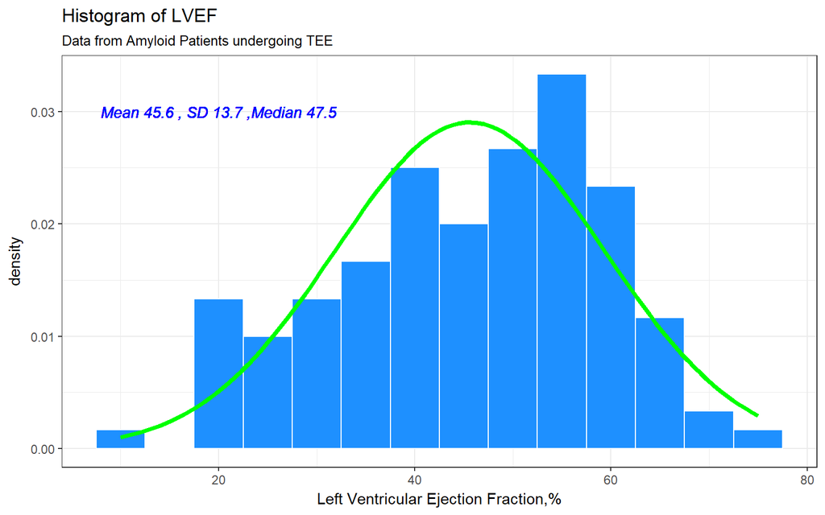

```r
ggplot(data=amyloid.f,aes(x=lvef))+
  geom_histogram(aes(y=..density..),col="white",fill="dodgerblue",binwidth =5 )+
  stat_function(fun = dnorm,
args = list(mean = mean(amyloid.f$lvef), sd = sd(amyloid.f$lvef)),
lwd = 1.5, col = "green")+
  geom_text(aes(label = paste("Mean", round(mean(amyloid.f$lvef),1),
", SD", round(sd(amyloid.f$lvef),1),",Median",round(median(amyloid.f$lvef),1))),
x = 20, y = .03, color="blue", fontface = "italic")+
  labs(x="Left Ventricular Ejection Fraction,%",title="Histogram of LVEF",subtitle="Data from Amyloid Patients undergoing TEE")+
  theme_bw()
```

We can see from this histogram that the data looks fairly normally distributed. The histogram also matches our skim with a low value of 10% and a high value of 75%. We can also look at a qq plot of the data.

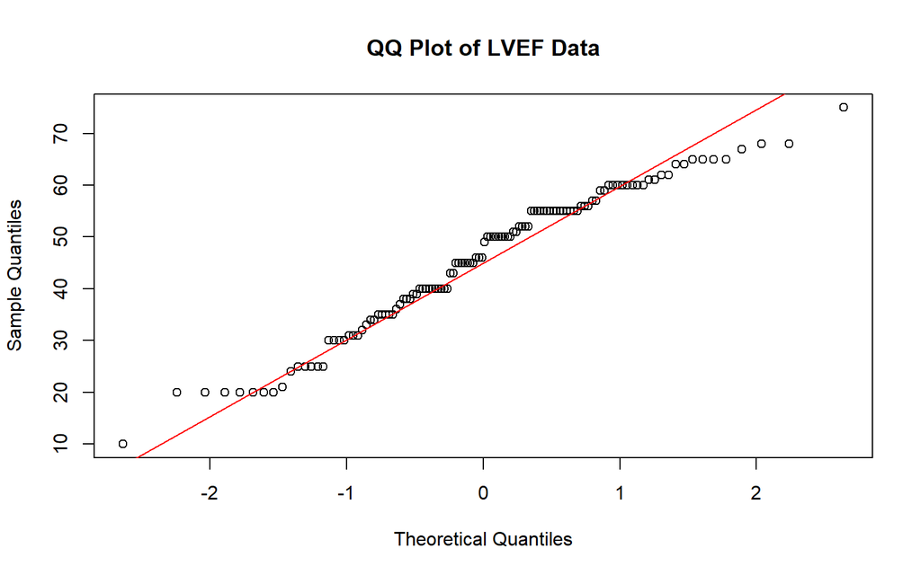

```r
qqnorm(amyloid.f$lvef,main="QQ Plot of LVEF Data")
qqline(amyloid.f$lvef,col="red")
```

## 10.2 Thinking of predictor variables

### 10.2.1 Looking at Relationships Between Outcome and Predictors

Looking at our data set there are several potential predictor variables that we could look at for our outcome of `lvef`. These include: `age`, `sex`, `primary_rhy`,`HTN`,`Diab`, `af`, and `CAD`. We know that we only have 120 observations thus if we included all these variables it is possible that we would overfit our data. Given our 120 variables we have 7 degrees of freedom to spend plus the intercept.

We can first visualize our outcome’s relationship to these predictors using a scatterplot matrix.

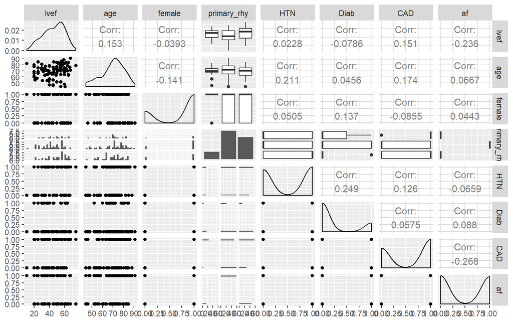

```r
GGally::ggpairs(dplyr::select(amyloid.f,lvef,age,female,primary_rhy,HTN,Diab,CAD,af))
```

We can see from our correlations that there does not seem to be an extremely strong correlation between any of the variables and `lvef`.

We can look at a spearman rho plot to see which of our predictor variables would be better to include in the model.

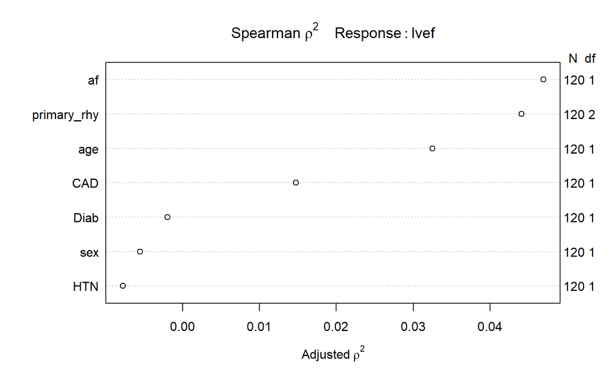

```r
plot(spearman2(lvef~age+sex+primary_rhy+HTN+Diab+CAD+af,data=amyloid.f))
```

We can see that`af`,`primary_rhy` and `age` seem to carry the most predictive power with`CAD` next in line. The variable that we originally wanted to include in our model `HTN` seems to have the least amount of predictive power so maybe we will leave that out of our model for now.

Let’s now look at some of the predictor variables more specifically.

### 10.2.2 Visualizing LVEF and Primary Rhythm

Question: Is there a better way to graph this?

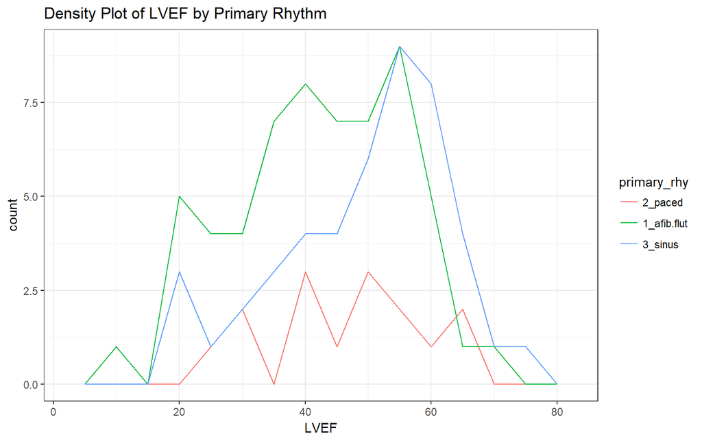

```r
ggplot(amyloid.f,aes(x=lvef,color=primary_rhy))+
  geom_freqpoly(binwidth=5)+
  theme_bw()+
  labs(x="LVEF",title="Density Plot of LVEF by Primary Rhythm")
```

Looking at this plot the biggest difference seems to be whether an individual was in atrial fibrillation or not as atrial fibrillation looks to have lower LVEFs than sinus and paced rhythms.

### 10.2.3 Visualizing LVEF and Age

We can create a scatterplot to visualize the relationship between `lvef` and `age` to see if it follows a linear pattern.

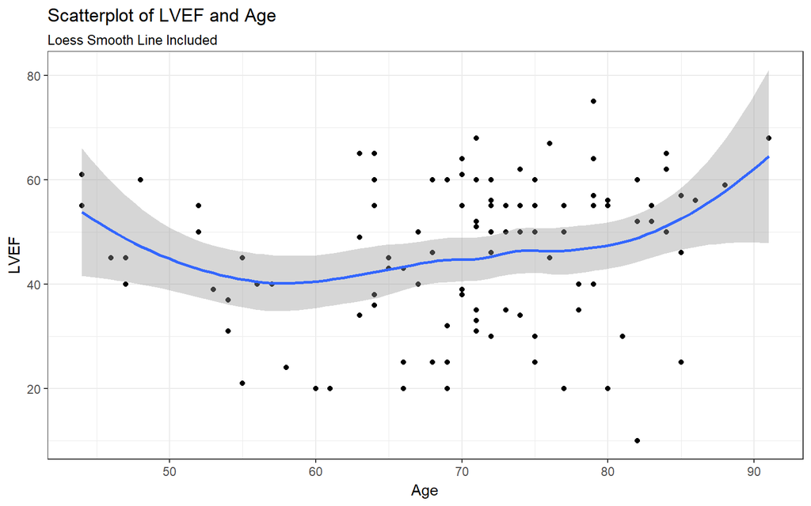

```r
ggplot(amyloid.f,aes(x=age,y=lvef))+
  geom_point()+
  geom_smooth(method="loess")+
  theme_bw()+
  labs(x="Age",y="LVEF",title="Scatterplot of LVEF and Age",subtitle="Loess Smooth Line Included")
```

Looking at the loess smooth of this relationship it does not seem linear and rather looks quadratic in nature. So we may consider spending a degree of freedom making this variable either quadratic or a 2 degree orthogonal polynomial.

### 10.2.4 Looking at the Relationship Between Age and Rhythm

We know that clinically people have a higher chance of abnormal rhythms (especially atrial fibrillation) as the age. We can graph this relationship to see if it played out in our data.

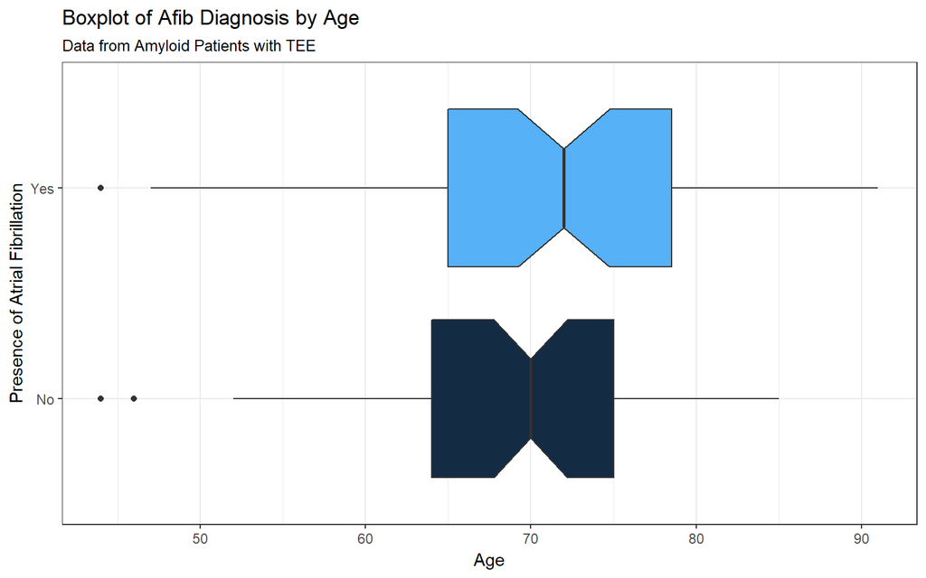

```r
ggplot(amyloid.f,aes(x=af_f,y=age,fill=af))+
  geom_boxplot(notch=T)+
  guides(fill="none")+
  labs(x="Presence of Atrial Fibrillation",y="Age",title="Boxplot of Afib Diagnosis by Age",subtitle="Data from Amyloid Patients with TEE")+
  coord_flip()+
  theme_bw()
```

It looks like individuals with atrial fibrillation tend to be older, but there is likely not a significant difference in our data set given that the notches of the boxplot overlap.

## 10.3 Choosing predictor variables

For our model. I would like to look at the following predictors:

- `age` as a 2 degree orthogonal polynomial
- `primary_rhy`
- `CAD`
- `af`
- `age`*`af` the interaction term between age and atrial fibrillation

This model uses 7 degrees of freedom which works with the number of observations that we have.

## 10.4 Do we need to transform our outcome?

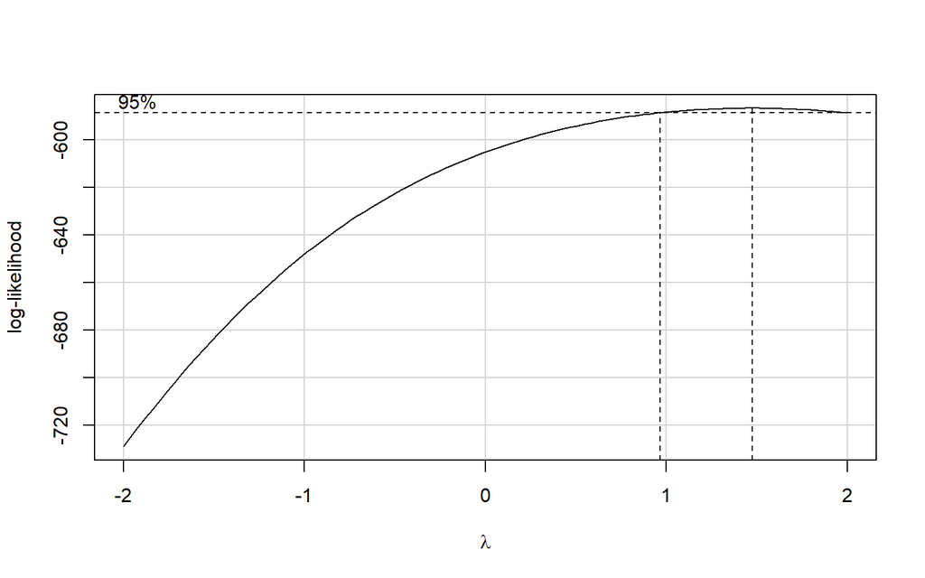

```r
library(car)
boxCox(lm(lvef~poly(age,2)+primary_rhy+CAD+af+age*af,data=amyloid.f))
```

It looks like we should be ok not transforming our outcome measure as $\lambda$ appears to be close to 1.

## 10.5 Building Linear Models

### 10.5.1 Model A- Initial Attempt

```r
d<-datadist(amyloid.f)
options(datadist="d")
```

```r
modelA<-ols(lvef~poly(age,2)+primary_rhy+CAD+af+af%ia%age,data=amyloid.f,x=TRUE,y=TRUE)
modelA
```

```
Linear Regression Model

 ols(formula = lvef ~ poly(age, 2) + primary_rhy + CAD + af +
     af %ia% age, data = amyloid.f, x = TRUE, y = TRUE)

                 Model Likelihood     Discrimination
                    Ratio Test           Indexes
 Obs      120    LR chi2     25.68    R2       0.193
 sigma12.6646    d.f.            7    R2 adj   0.142
 d.f.     112    Pr(> chi2) 0.0006    g        6.737

 Residuals

     Min      1Q  Median      3Q     Max
 -32.917  -7.958   0.929   9.532  24.143


                         Coef    S.E.        t     Pr(>|t|)
 Intercept               43.7729 3.99490e+00 10.96 <0.0001
 1                       49.0359 1.97975e+01  2.48 0.0147
 2                       44.8178 1.34009e+01  3.34 0.0011
 primary_rhy=1_afib.flut 23.7881 1.24787e+16  0.00 1.0000
 primary_rhy=3_sinus      3.7960 3.80810e+00  1.00 0.3210
 CAD                      4.4078 2.60860e+00  1.69 0.0939
 af                              2.28400e-01
 af * age                -0.4016 1.24787e+16  0.00 1.0000
```

We’re getting a variable without a coefficient, `af`. This is because the category of `primary_rhy` is perfectly collinear with `af`.

We will drop the primary rhythm variable as clinically it seems that whether or not one has atrial fibrillation is more important.

### 10.5.2 Model B– Second Revision

```r
modelB<-ols(lvef~poly(age,2)+CAD+af+af%ia%age,data=amyloid.f,x=TRUE,y=TRUE)
modelB
```

```
Linear Regression Model

 ols(formula = lvef ~ poly(age, 2) + CAD + af + af %ia% age, data = amyloid.f,
     x = TRUE, y = TRUE)

                 Model Likelihood     Discrimination
                    Ratio Test           Indexes
 Obs      120    LR chi2     24.62    R2       0.186
 sigma12.6644    d.f.            5    R2 adj   0.150
 d.f.     114    Pr(> chi2) 0.0002    g        6.595

 Residuals

      Min       1Q   Median       3Q      Max
 -33.1262  -7.9572   0.5024   9.4224  24.2888


           Coef    S.E.    t     Pr(>|t|)
 Intercept 46.8744  2.4516 19.12 <0.0001
 1         48.0660 19.7682  2.43 0.0166
 2         44.5670 13.1186  3.40 0.0009
 CAD        4.0628  2.5856  1.57 0.1189
 af        19.8655 16.1628  1.23 0.2216
 af * age  -0.3876  0.2274 -1.70 0.0909
```

We can see that by removing the collinear terms we now get an intercept for every variable.

```r
anova(modelB)
```

```
                Analysis of Variance          Response: lvef

 Factor                                  d.f. Partial SS MS       F
 age  (Factor+Higher Order Factors)        3   2724.4594 908.1531 5.66
  All Interactions                         1    466.1928 466.1928 2.91
 CAD                                       1    396.0146 396.0146 2.47
 af  (Factor+Higher Order Factors)         2   1931.2596 965.6298 6.02
  All Interactions                         1    466.1928 466.1928 2.91
 af * age  (Factor+Higher Order Factors)   1    466.1928 466.1928 2.91
 REGRESSION                                5   4164.7766 832.9553 5.19
 ERROR                                   114  18284.2150 160.3879
 P
 0.0012
 0.0909
 0.1189
 0.0033
 0.0909
 0.0909
 0.0002
```

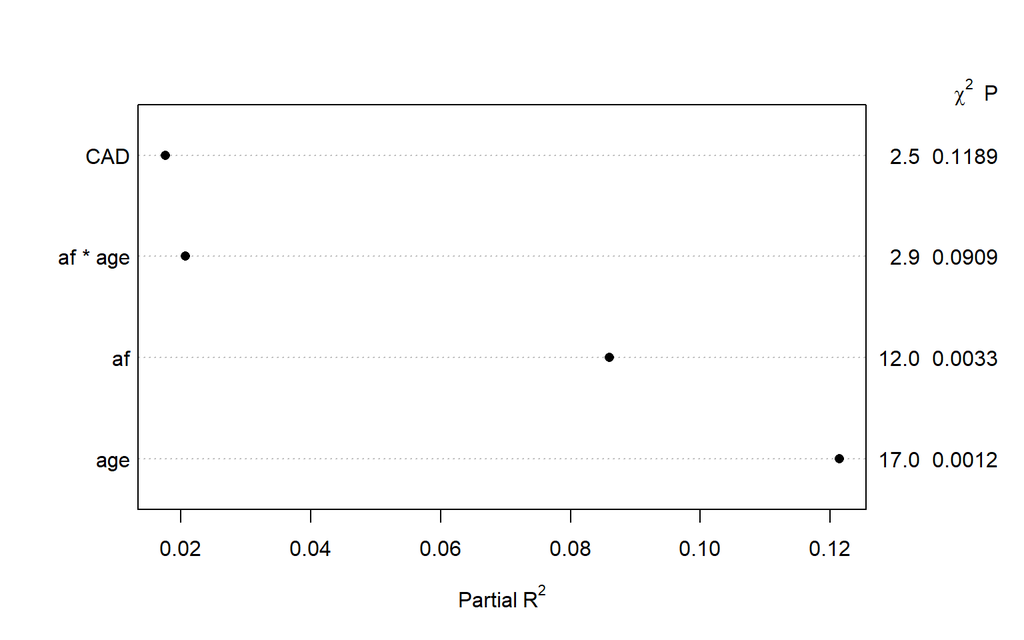

```r
plot(anova(modelB),what="partial")
```

From the anova it looks like the variables that provide significant impact on the outcome of the model and contribute to its R<sup>2</sup> are:

- `age`
- `af`

### 10.5.3 Model C- Dropping non-significant predictors

```r
modelC<-ols(lvef~poly(age,2)+af,data=amyloid.f,x=TRUE,y=TRUE)
modelC
```

```
Linear Regression Model

 ols(formula = lvef ~ poly(age, 2) + af, data = amyloid.f, x = TRUE,
     y = TRUE)

                 Model Likelihood     Discrimination
                    Ratio Test           Indexes
 Obs      120    LR chi2     20.03    R2       0.154
 sigma12.7977    d.f.            3    R2 adj   0.132
 d.f.     116    Pr(> chi2) 0.0002    g        6.075

 Residuals

     Min      1Q  Median      3Q     Max
 -36.988  -7.688   1.732   8.339  25.240


           Coef    S.E.    t     Pr(>|t|)
 Intercept 49.5982  1.6550 29.97 <0.0001
 1         25.8491 12.8273  2.02 0.0462
 2         40.1684 13.0275  3.08 0.0026
 af        -8.1488  2.3841 -3.42 0.0009
```

## 10.6 Comparing in Sample Model Performance

```r
glance(modelA)
```

```
  r.squared adj.r.squared    sigma statistic      p.value df   logLik
1 0.1926401     0.1497714 12.66464  4.493727 0.0004051566  7 -471.324
       AIC      BIC df.residual
1 960.6481 985.7355         113
```

```r
glance(modelB)
```

```
  r.squared adj.r.squared    sigma statistic      p.value df    logLik
1 0.1855218      0.149799 12.66443  5.193382 0.0002484941  6 -471.8507
       AIC      BIC df.residual
1 957.7014 977.2139         114
```

```r
glance(modelC)
```

```
  r.squared adj.r.squared   sigma statistic      p.value df    logLik
1 0.1536989     0.1318118 12.7977  7.022353 0.0002216959  4 -474.1504
       AIC      BIC df.residual
1 958.3007 972.2382         116
```

[output not shown]

Comparing the three models, Model B performed the best with regards to AIC while model C performed the best with regards to BIC (which we would predict since it is smaller).

## 10.7 Comparing the models in a test sample

```r
set.seed(20180307);validate(modelB,method="boot",B=40)
```

```
          index.orig training     test optimism index.corrected  n
R-square      0.1855   0.2201   0.1501   0.0700          0.1155 40
MSE         152.3685 143.8964 158.9965 -15.1001        167.4685 40
g             6.5953   7.0824   6.2367   0.8457          5.7496 40
Intercept     0.0000   0.0000   4.8732  -4.8732          4.8732 40
Slope         1.0000   1.0000   0.8949   0.1051          0.8949 40
```

```r
set.seed(20180307);validate(modelC,method="boot",B=40)
```

```
          index.orig training     test optimism index.corrected  n
R-square      0.1537   0.1820   0.1285   0.0535          0.1002 40
MSE         158.3217 150.9883 163.0407 -12.0524        170.3741 40
g             6.0752   6.4412   5.8399   0.6013          5.4739 40
Intercept     0.0000   0.0000   3.6959  -3.6959          3.6959 40
Slope         1.0000   1.0000   0.9206   0.0794          0.9206 40
```

| Model | Index Corrected R<sup>2</sup> | MSE |
| --- | --- | --- |
| Model B | 0.1155 | 167.47 |
| Model C | 0.1002 | 170.37 |

In out of sample testing model B performs better based on both the index corrected R<sup>2</sup> and MSE.

## 10.8 Make Predictions of New Data

```r
Predict(modelB, age =40:50, af=1,CAD=0,conf.type = 'simult')
```

```
   age af CAD     yhat    lower     upper
1   40  1   0 51.14277 27.85218  74.43337
2   41  1   0 41.64464 26.75145  56.53783
3   42  1   0 35.18948 23.46421  46.91476
4   43  1   0 31.77732 18.38407  45.17056
5   44  1   0 31.40813 14.99278  47.82349
6   45  1   0 34.08193 15.06178  53.10208
7   46  1   0 39.79872 18.76593  60.83151
8   47  1   0 48.55849 25.54857  71.56841
9   48  1   0 60.36124 34.41476  86.30772
10  49  1   0 75.20698 44.28850 106.12545
11  50  1   0 93.09570 54.46930 131.72209

Response variable (y): lvef

Limits are 0.95 confidence limits
```

[output not shown]

Sneha Vakamudi

2018-03-08 08:53:03